# Environmental Data Screening and Exploratory Analysis

Exploring publicly available water quality and nutrient profiles at 40 sites in Puget Sound

Author

Chris Mantegna

Published

October 26, 2026

# Purpose and decision rules

This report is a **source-screening document** only. The purpose is to review and assess publicly available data, gathered by local and regional agencies, to support future assessments of *Mytilus trossulus*’ response to environmental conditions. The data in this report was taken from the WA Department of Ecology (DoE). All raw data was reformatted from its original embedded vector format by manipulation into tables and combined across years and type prior to this process.

**Stages:** inventory → structural validation → data quality → descriptive EDA → sampling coverage → depth/season/site characterization → suitability decision. The current pilot uses two derived tables from the same DoE NetCDF file groups.

**QC limit:** The default `apply_qc: false` means all outputs are *provisional*. All posted data is QC’d by DoE, therefore the QC flags are only for my future intended use.

**Sampling units:** Depth observations are nested within profiles; profiles are nested within stations and time. Nutrients are discrete samples at selected depths. The source webpage lists units for profile parameters and all five discrete nutrients (including phosphate at µM); correspondence between the webpage and the extracted NetCDF variables still requires confirmation.

# A. Setup, source registration and file checks

| source_id | source_label | provider | platform | source_family | raw_format | derived_files | source_url | download_date | spatial_reference | temporal_resolution | vertical_reference | units_verified | qc_reviewed | responsible_reviewer | notes |
| --- | --- | --- | --- | --- | --- | --- | --- | --- | --- | --- | --- | --- | --- | --- | --- |
| DOE_EIM_MarineWater_2019_2025 | WA Ecology EIM Marine Water Profiles and Nutrients | Washington Department of Ecology | EIM | Marine water profiles and nutrients | NetCDF (.nc) | abiotic_all.csv; nutrients_all.csv | NA | NA | Station coordinates (validate datum/CRS) | Repeated sampling profiles | Meters below surface (verify yearly metadata) | FALSE | FALSE | NA | Pilot screening; complete registry fields from original metadata |

## A1. Read the two working tables

| table | rows | stations | profiles |
| --- | --- | --- | --- |
| abiotic | 48543 | 40 | 1773 |
| nutrients | 5416 | 39 | 1744 |

## A2. Identifier and duplication audit

| table | exact_duplicate_rows | missing_station | missing_profile | missing_date | missing_depth | negative_depth | profile_station_conflicts |
| --- | --- | --- | --- | --- | --- | --- | --- |
| abiotic | 6919 | 0 | 0 | 0 | 0 | 0 | 0 |
| nutrients | 754 | 0 | 0 | 0 | 0 | 0 | 0 |

# B. QC review and data integrity (pre-cleaning)

## B1. Variable dictionary

The Ecology marine-water data webpage lists nitrate, nitrite, ammonium, phosphate, and silicate in micromolar (µM), not µg/L. Units below are documented from the [DoE webpage](https://ecology.wa.gov/research-data/monitoring-assessment/puget-sound-and-marine-monitoring), pending verification against individual NetCDF variable attributes and any year-specific differences. No numeric unit conversion is performed.

| variable | source_variable | category | unit | unit_source | qc_field | accepted_qc_definition | reporting_limit | measurement_method | year_changes | review_status |
| --- | --- | --- | --- | --- | --- | --- | --- | --- | --- | --- |
| temperature | Temp | abiotic sensor | °C | Ecology webpage: profile parameters | NA | NA | NA | NA | NA | Webpage unit found; verify against NetCDF metadata |
| salinity | Salinity | abiotic sensor | PSU | Ecology webpage: profile parameters | NA | NA | NA | NA | NA | Webpage unit found; verify against NetCDF metadata |
| dissolved_oxygen | DOAdjusted | abiotic sensor | mg/L | Ecology webpage: profile parameters | NA | NA | NA | NA | NA | Webpage unit found; verify against NetCDF metadata |
| nitrate | NO3 | discrete nutrient | µM | Ecology webpage: discrete nutrients | NA | NA | NA | NA | NA | Webpage unit found; verify against NetCDF metadata |
| nitrite | NO2 | discrete nutrient | µM | Ecology webpage: discrete nutrients | NA | NA | NA | NA | NA | Webpage unit found; verify against NetCDF metadata |
| ammonium | NH4 | discrete nutrient | µM | Ecology webpage: discrete nutrients | NA | NA | NA | NA | NA | Webpage unit found; verify against NetCDF metadata |
| phosphate | PO4 | discrete nutrient | µM | Ecology webpage: discrete nutrients (user confirmed) | NA | NA | NA | NA | NA | Webpage unit found; verify against NetCDF metadata |
| silicate | SiOH4 | discrete nutrient | µM | Ecology webpage: discrete nutrients | NA | NA | NA | NA | NA | Webpage unit found; verify against NetCDF metadata |

## B2. Missing, sentinel, non-finite and negative value audit

*Note:* nutrients are sampled at specific depths and cycles rather than at all depths and repeatedly throughout each month of the year - ‘missing’ records does not mean missing in the same way that the water quality parameters are missing.

Sentinel values are those (like -999) that represent a missing, invalid, or measurement tool limitation. Non-finite are values (like NA) that require further review to confirm, and negative values may or may not be valid based on the measurement category, so it is flagged for review.

| table | sample_year | variable | n_records | n_missing_na | n_nonfinite | n_sentinel | n_negative | pct_nonfinite | n_valid | min | q25 | median | mean | q75 | max | sd |
| --- | --- | --- | --- | --- | --- | --- | --- | --- | --- | --- | --- | --- | --- | --- | --- | --- |
| abiotic | 2019 | dissolved_oxygen | 9356 | 180 | 180 | 0 | 0 | 1.92 | 9176 | 1.27 | 7.02 | 8.22 | 8.33 | 9.54 | 17.79 | 1.98 |
| abiotic | 2019 | salinity | 9356 | 64 | 64 | 0 | 0 | 0.68 | 9292 | 9.10 | 28.70 | 29.54 | 28.93 | 30.22 | 31.67 | 2.31 |
| abiotic | 2019 | temperature | 9356 | 41 | 41 | 0 | 0 | 0.44 | 9315 | 5.13 | 9.33 | 10.93 | 11.39 | 13.08 | 21.58 | 2.72 |
| abiotic | 2020 | dissolved_oxygen | 3241 | 156 | 156 | 0 | 0 | 4.81 | 3085 | 1.73 | 7.00 | 7.90 | 7.83 | 8.59 | 13.31 | 1.47 |
| abiotic | 2020 | salinity | 3241 | 18 | 18 | 0 | 0 | 0.56 | 3223 | 14.08 | 28.07 | 29.19 | 28.22 | 29.86 | 31.18 | 2.93 |
| abiotic | 2020 | temperature | 3241 | 14 | 14 | 0 | 0 | 0.43 | 3227 | 6.55 | 8.44 | 8.90 | 9.39 | 10.02 | 13.91 | 1.39 |
| abiotic | 2022 | dissolved_oxygen | 8554 | 1145 | 1145 | 0 | 0 | 13.39 | 7409 | 0.55 | 7.00 | 8.31 | 8.20 | 9.39 | 18.01 | 1.95 |
| abiotic | 2022 | salinity | 8554 | 136 | 136 | 0 | 0 | 1.59 | 8418 | 6.07 | 27.53 | 28.71 | 27.85 | 29.84 | 32.00 | 3.28 |
| abiotic | 2022 | temperature | 8554 | 95 | 95 | 0 | 0 | 1.11 | 8459 | 5.94 | 8.55 | 10.13 | 10.81 | 12.19 | 22.32 | 2.92 |
| abiotic | 2023 | dissolved_oxygen | 13830 | 280 | 280 | 0 | 0 | 2.02 | 13550 | 0.30 | 6.87 | 8.39 | 8.35 | 9.57 | 17.57 | 2.08 |
| abiotic | 2023 | salinity | 13830 | 96 | 96 | 0 | 0 | 0.69 | 13734 | 11.77 | 28.87 | 29.47 | 28.88 | 30.31 | 31.88 | 2.58 |
| abiotic | 2023 | temperature | 13830 | 96 | 96 | 0 | 0 | 0.69 | 13734 | 6.46 | 9.43 | 11.49 | 11.85 | 13.64 | 22.46 | 3.08 |
| abiotic | 2024 | dissolved_oxygen | 7339 | 104 | 104 | 0 | 0 | 1.42 | 7235 | 0.28 | 7.08 | 8.07 | 8.16 | 9.38 | 17.56 | 2.07 |
| abiotic | 2024 | salinity | 7339 | 27 | 27 | 0 | 0 | 0.37 | 7312 | 13.05 | 28.68 | 29.39 | 29.01 | 30.15 | 32.36 | 2.08 |
| abiotic | 2024 | temperature | 7339 | 2 | 2 | 0 | 0 | 0.03 | 7337 | 4.62 | 9.42 | 10.88 | 11.43 | 12.80 | 25.66 | 2.59 |
| abiotic | 2025 | dissolved_oxygen | 6223 | 1009 | 1009 | 0 | 0 | 16.21 | 5214 | 0.14 | 6.32 | 7.48 | 7.65 | 8.75 | 17.32 | 2.07 |
| abiotic | 2025 | salinity | 6223 | 63 | 63 | 0 | 0 | 1.01 | 6160 | 7.54 | 28.50 | 29.60 | 28.77 | 30.45 | 33.30 | 3.07 |
| abiotic | 2025 | temperature | 6223 | 60 | 60 | 0 | 0 | 0.96 | 6163 | 6.10 | 9.52 | 11.10 | 11.30 | 12.54 | 21.37 | 2.50 |
| nutrients | 2019 | ammonium | 1051 | 0 | 0 | 0 | 0 | 0.00 | 1051 | 0.00 | 0.09 | 0.61 | 1.01 | 1.57 | 9.36 | 1.21 |
| nutrients | 2019 | nitrate | 1051 | 0 | 0 | 0 | 0 | 0.00 | 1051 | 0.00 | 12.57 | 20.98 | 18.46 | 26.06 | 31.15 | 8.79 |
| nutrients | 2019 | nitrite | 1051 | 0 | 0 | 0 | 0 | 0.00 | 1051 | 0.01 | 0.19 | 0.33 | 0.33 | 0.44 | 1.07 | 0.19 |
| nutrients | 2019 | phosphate | 1051 | 0 | 0 | 0 | 0 | 0.00 | 1051 | 0.07 | 1.64 | 2.05 | 1.95 | 2.38 | 4.31 | 0.67 |
| nutrients | 2019 | silicate | 1051 | 0 | 0 | 0 | 0 | 0.00 | 1051 | 1.54 | 36.38 | 45.86 | 46.24 | 55.38 | 112.94 | 14.96 |
| nutrients | 2020 | ammonium | 367 | 0 | 0 | 0 | 0 | 0.00 | 367 | 0.00 | 0.00 | 0.10 | 0.71 | 0.72 | 49.74 | 2.76 |
| nutrients | 2020 | nitrate | 367 | 0 | 0 | 0 | 0 | 0.00 | 367 | 0.14 | 25.74 | 27.67 | 26.44 | 29.52 | 31.89 | 4.95 |
| nutrients | 2020 | nitrite | 367 | 0 | 0 | 0 | 0 | 0.00 | 367 | 0.00 | 0.11 | 0.21 | 0.27 | 0.37 | 0.96 | 0.20 |
| nutrients | 2020 | phosphate | 367 | 0 | 0 | 0 | 0 | 0.00 | 367 | 0.63 | 2.23 | 2.39 | 2.35 | 2.58 | 4.01 | 0.45 |
| nutrients | 2020 | silicate | 367 | 0 | 0 | 0 | 0 | 0.00 | 367 | 31.33 | 51.42 | 60.47 | 60.84 | 67.12 | 125.84 | 12.62 |
| nutrients | 2022 | ammonium | 900 | 0 | 0 | 0 | 0 | 0.00 | 900 | 0.00 | 0.11 | 0.55 | 1.15 | 1.55 | 26.98 | 1.79 |
| nutrients | 2022 | nitrate | 900 | 0 | 0 | 0 | 0 | 0.00 | 900 | 0.00 | 14.92 | 24.86 | 21.11 | 28.37 | 33.10 | 9.15 |
| nutrients | 2022 | nitrite | 900 | 0 | 0 | 0 | 0 | 0.00 | 900 | 0.01 | 0.18 | 0.31 | 0.32 | 0.41 | 1.71 | 0.19 |
| nutrients | 2022 | phosphate | 900 | 0 | 0 | 0 | 0 | 0.00 | 900 | 0.06 | 1.77 | 2.21 | 2.07 | 2.51 | 6.24 | 0.72 |
| nutrients | 2022 | silicate | 900 | 0 | 0 | 0 | 0 | 0.00 | 900 | 2.38 | 34.78 | 41.48 | 43.17 | 50.72 | 141.93 | 13.64 |
| nutrients | 2023 | ammonium | 1508 | 0 | 0 | 0 | 0 | 0.00 | 1508 | 0.00 | 0.37 | 0.97 | 1.62 | 2.12 | 104.00 | 4.06 |
| nutrients | 2023 | nitrate | 1508 | 0 | 0 | 0 | 0 | 0.00 | 1508 | 0.00 | 11.09 | 19.20 | 17.51 | 26.07 | 34.46 | 9.56 |
| nutrients | 2023 | nitrite | 1508 | 0 | 0 | 0 | 0 | 0.00 | 1508 | 0.00 | 0.22 | 0.35 | 0.39 | 0.50 | 1.96 | 0.26 |
| nutrients | 2023 | phosphate | 1508 | 0 | 0 | 0 | 0 | 0.00 | 1508 | 0.05 | 1.66 | 2.14 | 1.99 | 2.50 | 6.18 | 0.80 |
| nutrients | 2023 | silicate | 1508 | 0 | 0 | 0 | 0 | 0.00 | 1508 | 5.44 | 31.48 | 37.36 | 38.54 | 45.13 | 114.05 | 13.30 |
| nutrients | 2024 | ammonium | 887 | 0 | 0 | 0 | 0 | 0.00 | 887 | 0.00 | 0.09 | 0.56 | 1.23 | 1.64 | 38.48 | 2.10 |
| nutrients | 2024 | nitrate | 887 | 0 | 0 | 0 | 0 | 0.00 | 887 | 0.10 | 11.74 | 21.39 | 18.73 | 27.06 | 32.81 | 9.55 |
| nutrients | 2024 | nitrite | 887 | 1 | 1 | 0 | 0 | 0.11 | 886 | 0.00 | 0.19 | 0.31 | 0.32 | 0.42 | 2.96 | 0.20 |
| nutrients | 2024 | phosphate | 887 | 0 | 0 | 0 | 0 | 0.00 | 887 | 0.05 | 1.70 | 2.13 | 2.07 | 2.49 | 5.39 | 0.74 |
| nutrients | 2024 | silicate | 887 | 0 | 0 | 0 | 0 | 0.00 | 887 | 0.42 | 33.30 | 40.95 | 43.25 | 53.38 | 106.53 | 16.04 |
| nutrients | 2025 | ammonium | 703 | 0 | 0 | 0 | 0 | 0.00 | 703 | 0.00 | 0.06 | 0.48 | 1.15 | 1.52 | 38.01 | 2.04 |
| nutrients | 2025 | nitrate | 703 | 0 | 0 | 0 | 0 | 0.00 | 703 | 0.00 | 15.51 | 24.67 | 21.26 | 28.74 | 42.32 | 9.47 |
| nutrients | 2025 | nitrite | 703 | 0 | 0 | 0 | 0 | 0.00 | 703 | 0.00 | 0.20 | 0.31 | 0.35 | 0.46 | 1.59 | 0.22 |
| nutrients | 2025 | phosphate | 703 | 0 | 0 | 0 | 0 | 0.00 | 703 | 0.06 | 1.78 | 2.25 | 2.10 | 2.53 | 5.59 | 0.77 |
| nutrients | 2025 | silicate | 703 | 0 | 0 | 0 | 0 | 0.00 | 703 | 2.95 | 39.11 | 47.33 | 48.22 | 56.59 | 154.52 | 17.75 |

### Missing(ness) heatmap

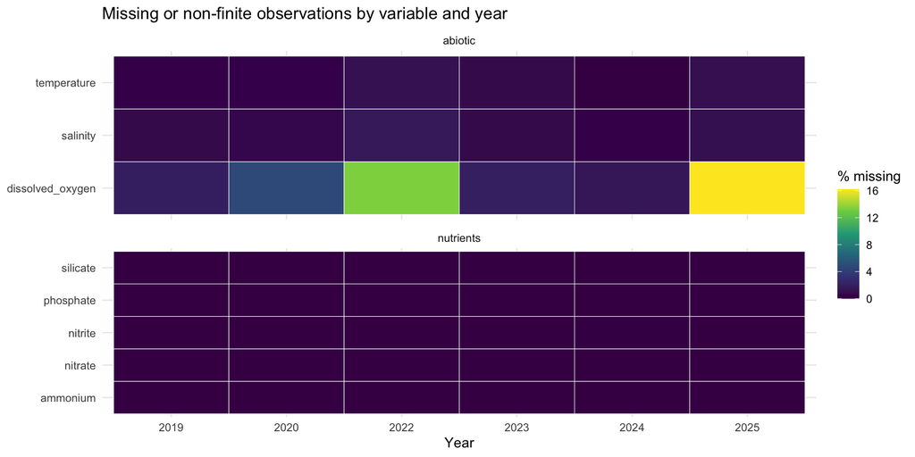

## B3. QC status and data cleaning

QC parameters for this project has not been defined, so this is a placeholder for the larger workflow. As stated earlier, all data hosted on DoE’s sites have been QC’d or is indicated otherwise in the study description.

```
**Analyst screening status:** No additional analyst QC filtering applied
```

# C. Distributions (raw data)

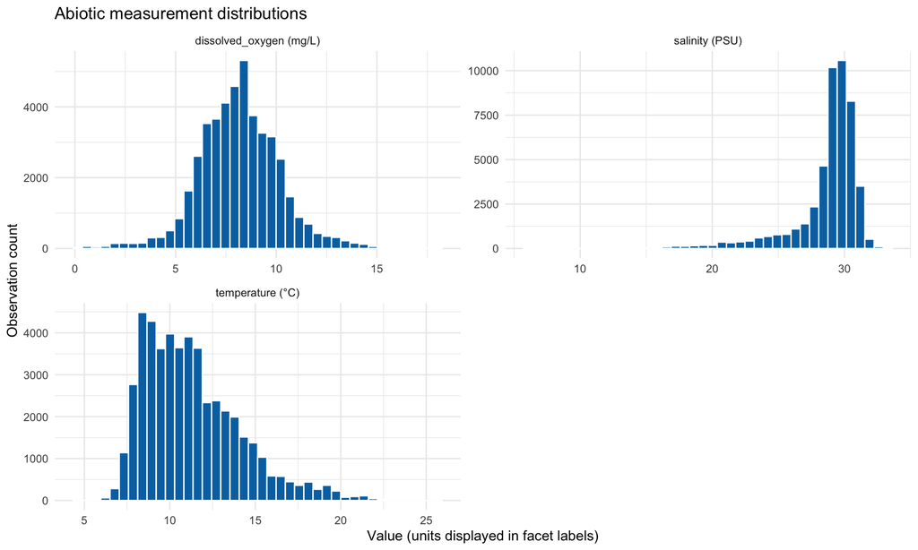

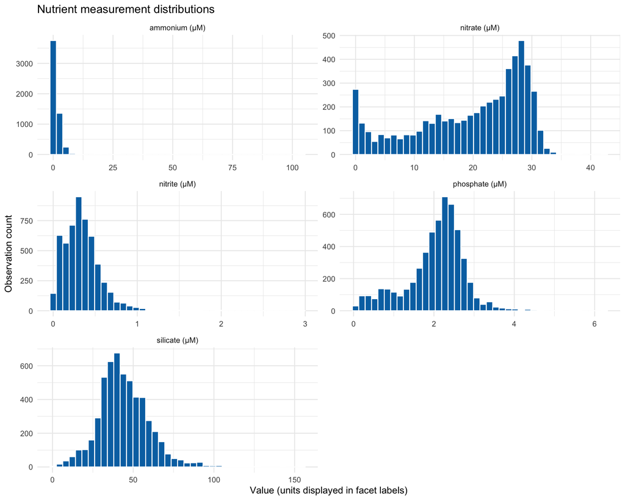

**Reminder:** Data, in particular, `nutrients_all` includes only rows with at least one observed nutrient, so its missing-ness percentages are conditional on that selection.

# D. Sampling coverage (before comparison)

## D1. Abiotic profile counts by station and year

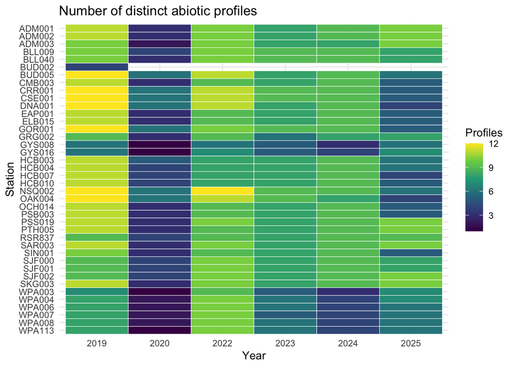

## D2. Nutrient sampling counts and depths

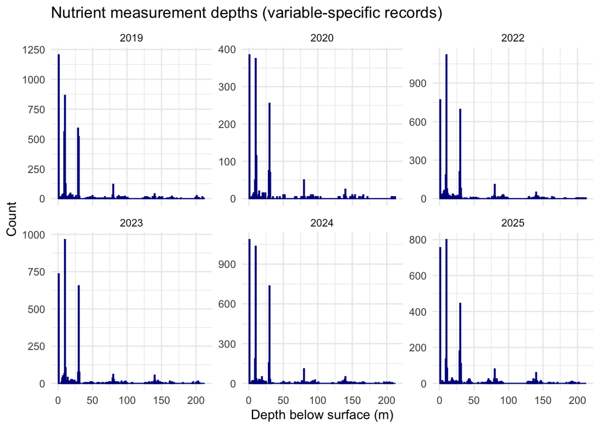

# E. Post-QC environmental patterns

**Interpretation limit:** These are exploratory summaries of Ecology-hosted measurements, not an additional Ecology QC determination. Analyst-level screening of suitability, NetCDF metadata, unit consistency, and sampling coverage remains incomplete. Do not treat these summaries as validated exposure covariates until that review is complete. This limitation is documented here rather than repeated on individual plots.

## E1. Abiotic profile-level summaries: 0–13 m

**Caution:** A profile reaching 12 m is not automatically well represented at every intermediate depth. Inspect number and spacing of bins and missing-ness per variable; profile means from incomplete sections of the rope can be biased. Depth-bin statistics are exploratory until coverage rules are set.

## E2. Monthly seasonality (profile means, not individual depth records)

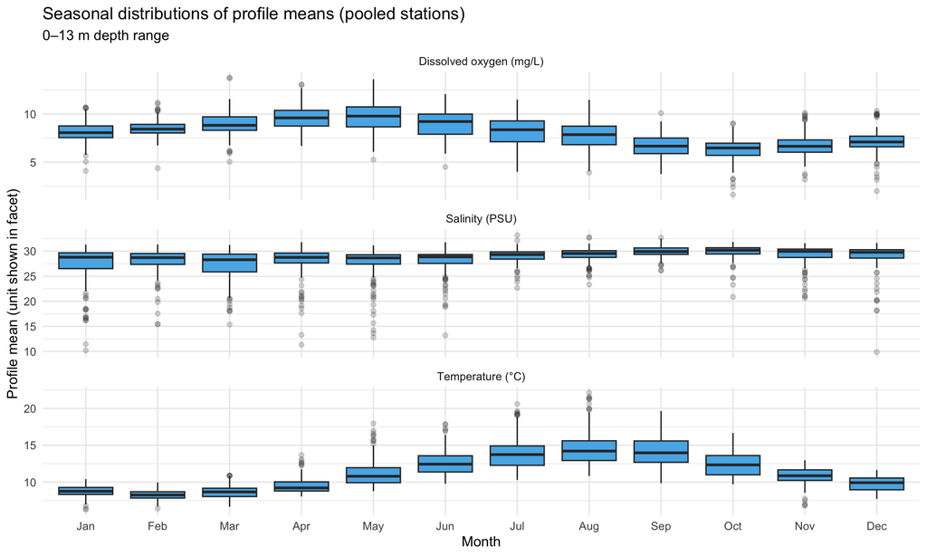

## E3. Depth strata: vertical exposure structure

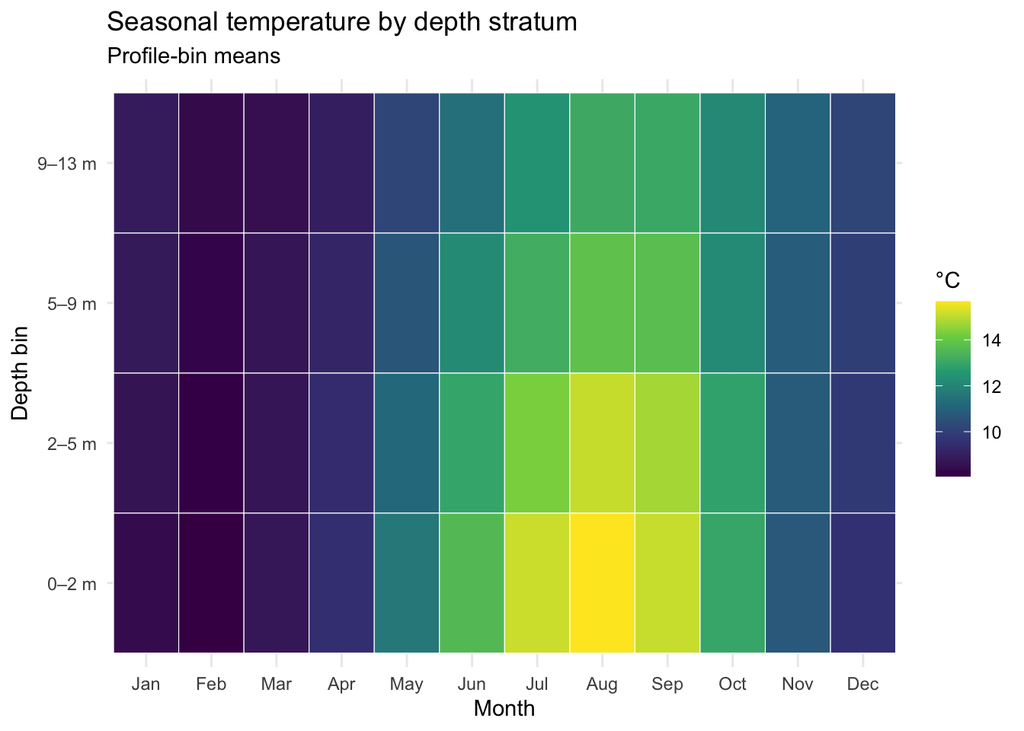

## E4. Nutrient seasonality: retaining discrete sample depths

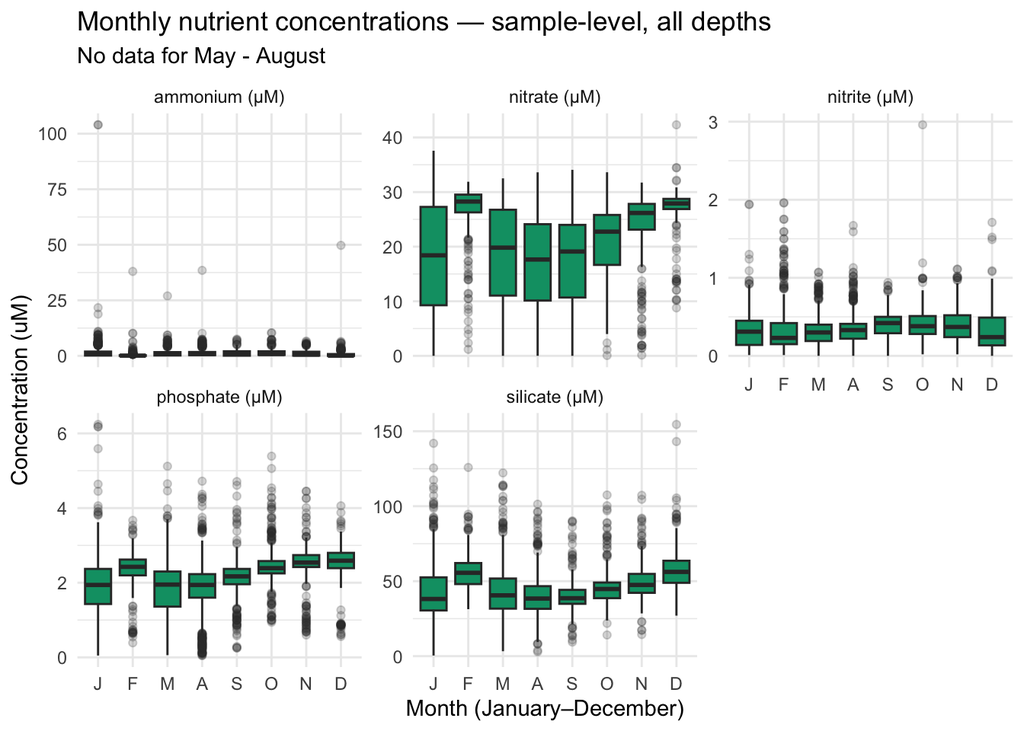

# F. Next Steps

**Goal: create an integrated environmental profile.** Before an IEP can be developed, I need to decide whether each source supports (1) regional environmental characterization, (2) station-specific characterization, and/or (3) linkage to existing mussel records.

## F1. Analysis completion checklist

- Source URL, retrieval date, version, spatial reference and methods recorded.
- Original data preserved without destructive alterations.
- Station identifiers resolved; station coordinates and positional uncertainty reviewed.
- All relevant QC variables and codes interpreted using source documentation.
- Sentinels, missing values and censored results distinguished.
- Measurement units reconciled across annual files and across agencies.
- Duplicate and profile/station identifier anomalies checked.
- Temporal and seasonal sampling effort described; years with method changes flagged.
- Sampling depth and rope-relevant depth coverage evaluated independently.
- Histograms, descriptive tables and sampling-effort plots reviewed and annotated.
- Inclusion decisions recorded separately for regional, station and mussel-linked work.
- Known limitations and follow-up tasks documented for future researchers.

## F2. Expansion to other sources

Each dataset that is available from contaminants to additional water quality and nutrient composition will undergo a similar EDA before combination, application, or interpretation.